# Prosper Loan Data Analysis- Part II

## by Oluwafunmito Blessed ODEFEMI

## Dataset Overview

The Prosper loan data set contains 113,937 loan records with each record containg information on loan amount, borrower rate (or interest rate), Annual Percentage Rate (APR), current loan status, borrower income, and many other features about the loan.

## Investigation Overview

In this data analysis process, I wanted to look at what affected the outcome of a loan among features such as the risk score, borrower rate/APR, home ownership, among other features.

# Some Interesting findings

## Number of Borrower Listing by Month

January has the highest number of borrowers, with 11214 listings, representing 9.8% of the dataset. In contrast, April had the least number of borrowers, with 7661 listings representing 6.7%.

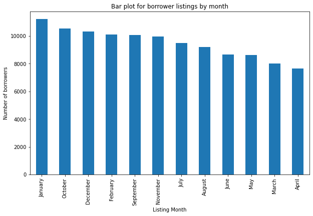

## Borrower Listing Category

More than half of borrowers did for debt consolidation, meaning they borrowed so they could pay off other loans.

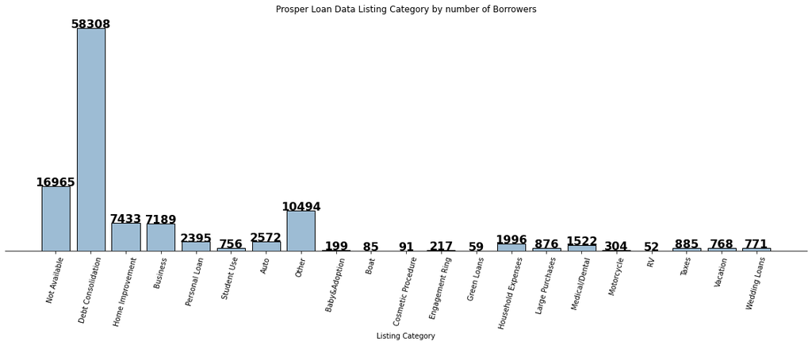

## Number of Borrowings by State

California (CA) had the highest number of listed borrowers, with over 14000 listings, which is not surprising, given its status as the most populous state and one of the most important commercial hubs in the country. In contrast, North Dakota had the lowest number of listings at just over 50.

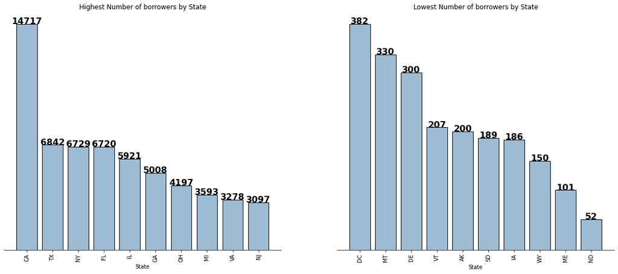

## Average Amount Borrowed weekly

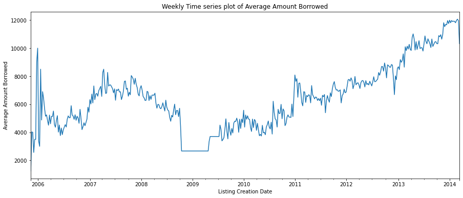

# Features of Interest

## ProsperScore vs LoanStatus

Borrowers with a prosper risk score of 7 were the most likely to complete their loan payments, while those with between 5 and 6 were more likely to default on their payments.

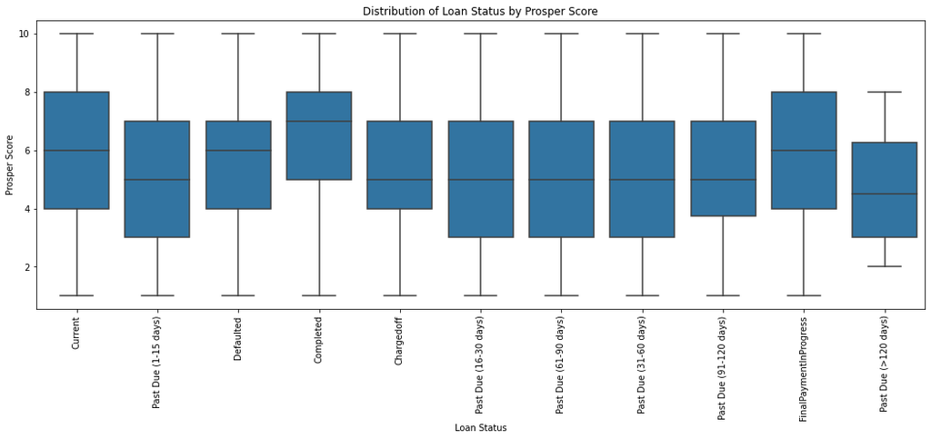

## LoanStatus vs BorrowerAPR/BorrowerRate

The higher a loan's rate/APR, the higher the chances of a borrower defaulting.

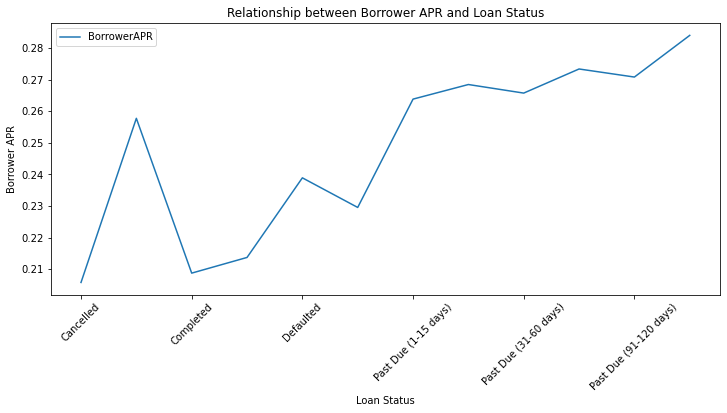

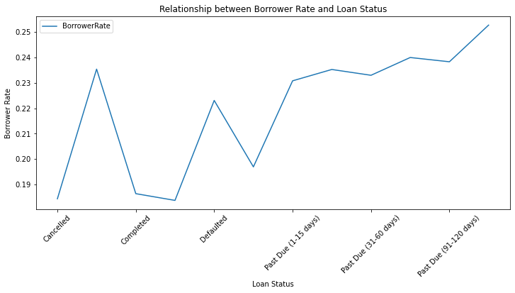

## LoanStatus vs LoanOriginalAmount

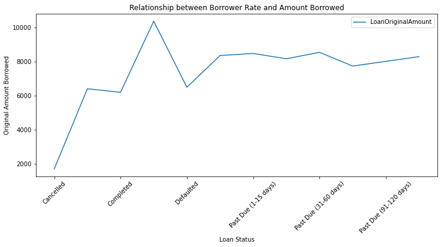

## LoanStatus vs Home ownership

There does not appear to be any significant difference between borrowers with homes and those without homes in the payments of the loan statuses.

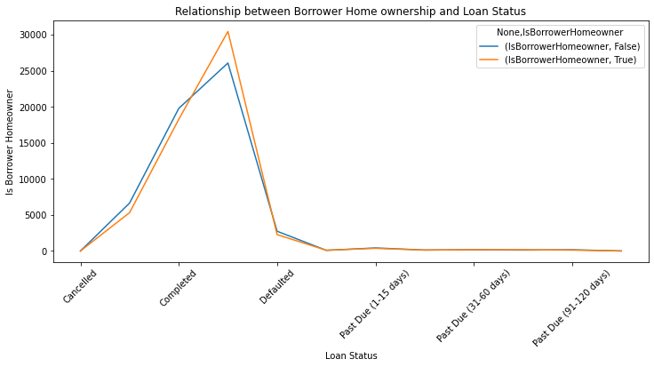